# r2dii.plot 0.2.0 is now on CRAN

New styling functions, new arguments to `plot_*()`, and bug fixes.

Mauro Lepore https://github.com/maurolepore  
2021-10-18

### Table of Contents

r2dii-plot 0.2.0 is now on CRAN. This is a minor release with new features, enhancements and bug fixes. This post focuses on the new features. For everything else see the [changelog](https://2degreesinvesting.github.io/r2dii.plot/news/).

You can install r2dii.plot from CRAN with:

```r
install.packages("r2dii.plot")
```

And you can use it with `library()`. Here we’ll also use the ggplot2 package.

```r
library(ggplot2, warn.conflicts = FALSE)
library(r2dii.plot)
```

### New styling functions

A new family of functions help you apply 2DII colour palettes to any plot.

Note this plot uses data and functions from the ggplot2 package exclusively.

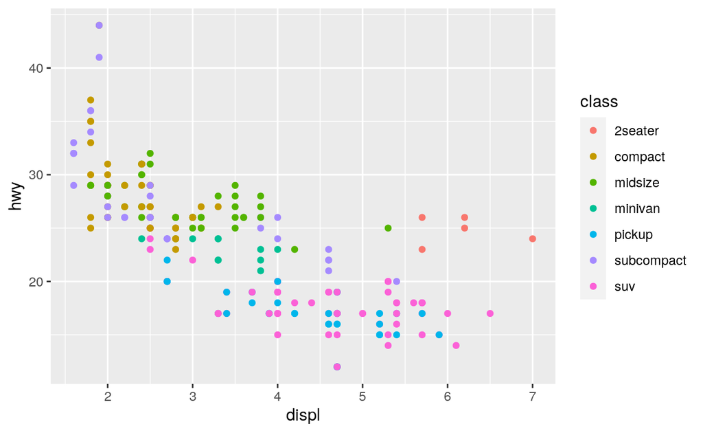

```r
p <- ggplot(mpg) + geom_point(aes(displ, hwy, color = class))
p
```

You can now use r2dii.plot to apply 2DII’s colour scale with:

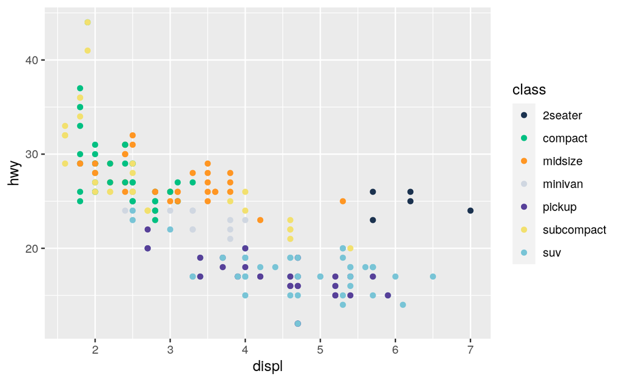

```r
p + scale_colour_r2dii()
```

To discover other functions in the “2dii scale” family run `?scale_colour_r2dii()` and navigate to the section “See also”.

### New arguments to `plot_*()`

The `plot_*()` functions gained new arguments to replicate features of the `qplot_*()` functions.

For example, compare these two plots. Note the shorter (5 years) time span and nicer legend labels in the plot created with `qplot_*()`.

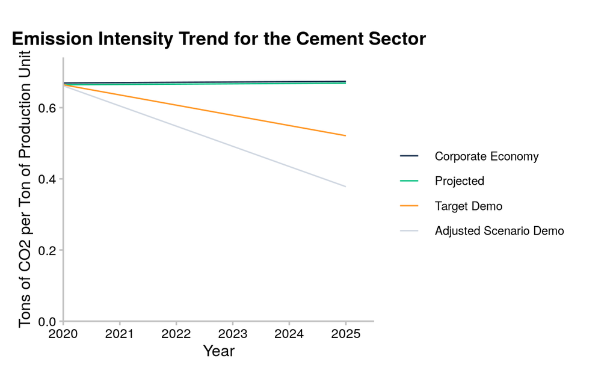

```r
data <- subset(sda, sector == "cement")

qplot_emission_intensity(data)
```

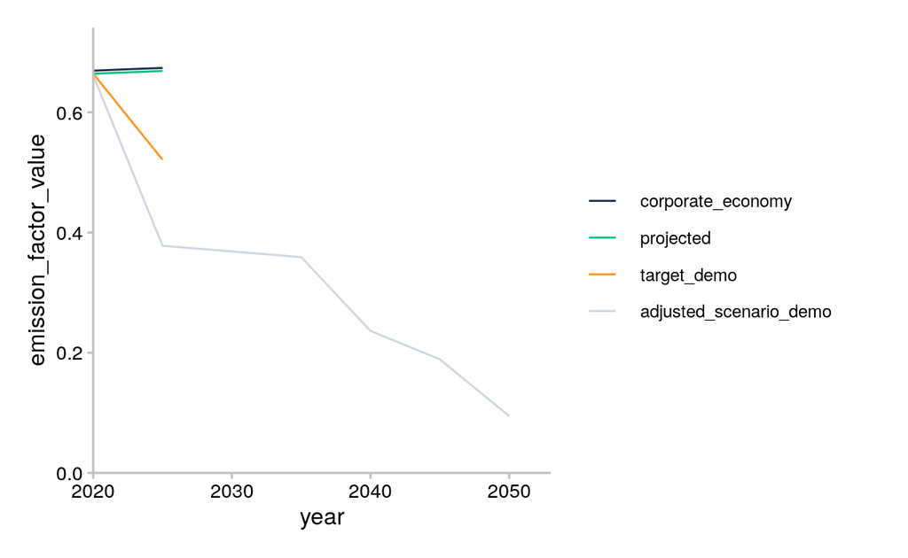

```r
plot_emission_intensity(data)
```

You can now replicate those features of `qplot_*()` with the new arguments `span_5yr` and `convert_label`:

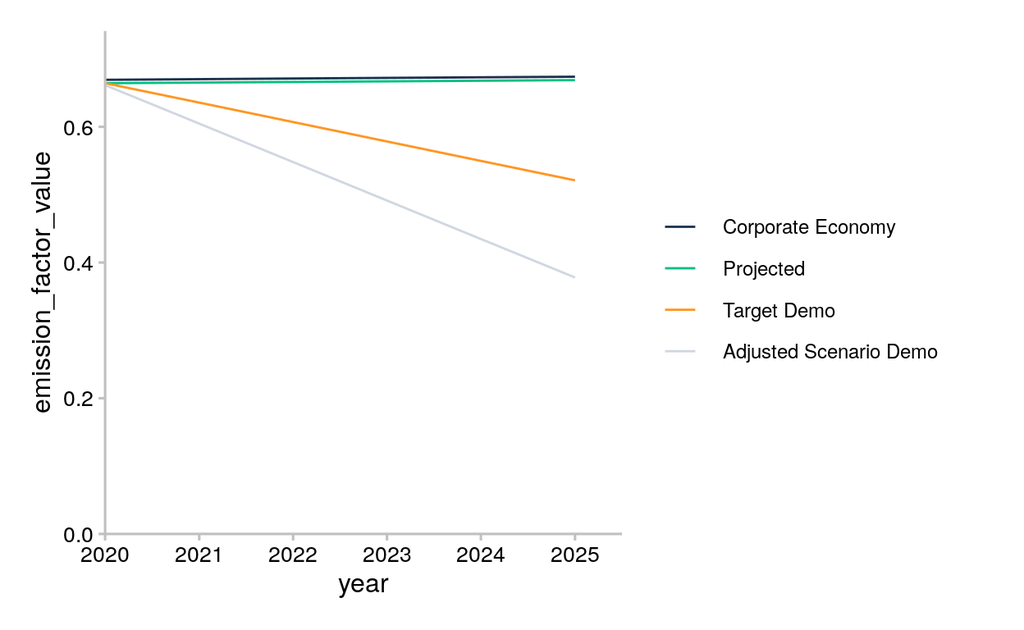

```r
plot_emission_intensity(data, span_5yr = TRUE, convert_label = to_title)
```

## Acknowledgements

Thanks to [@cjyetman](https://github.com/cjyetman) for [proposing the `scale_*()` functions](https://github.com/2DegreesInvesting/r2dii.plot/issues/28), to [@georgeharris2deg](https://github.com/georgeharris2deg) for reporting bugs, and to all contributors to this release (AlexAxthelm, maurolepore, MonikaFu).